# 红酒数据集探索性数据分析

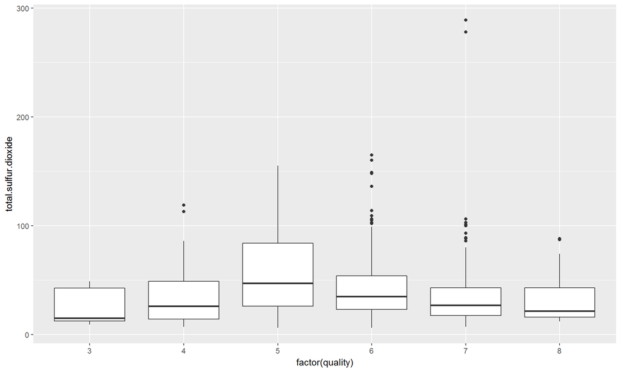

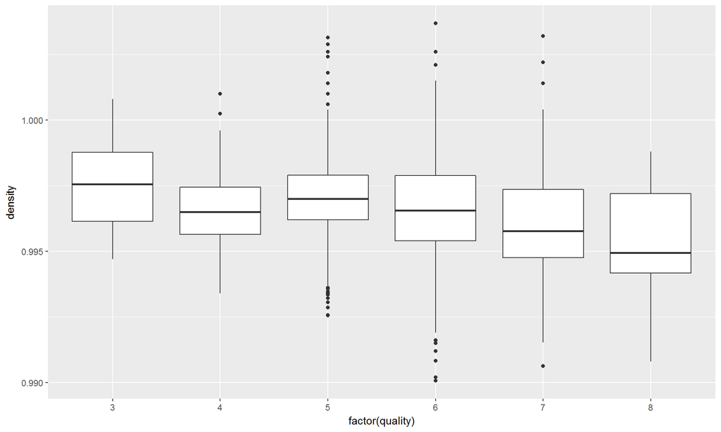

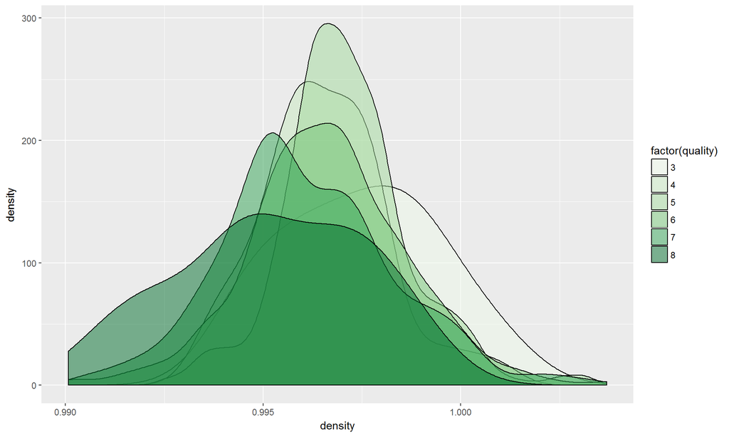

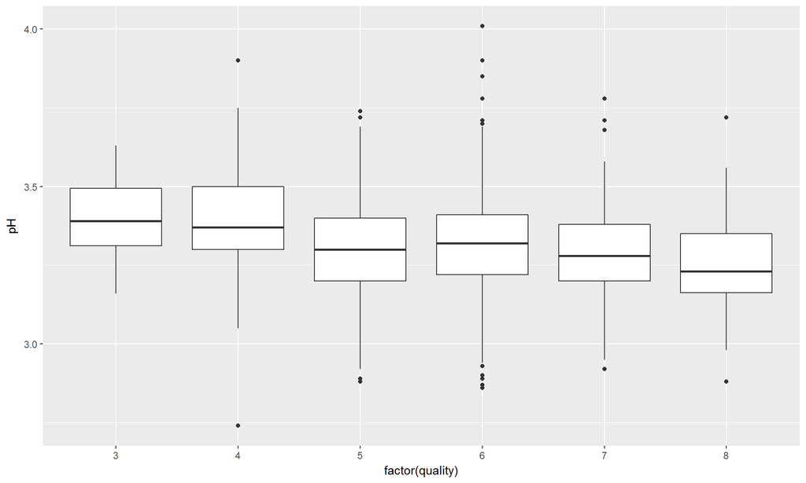

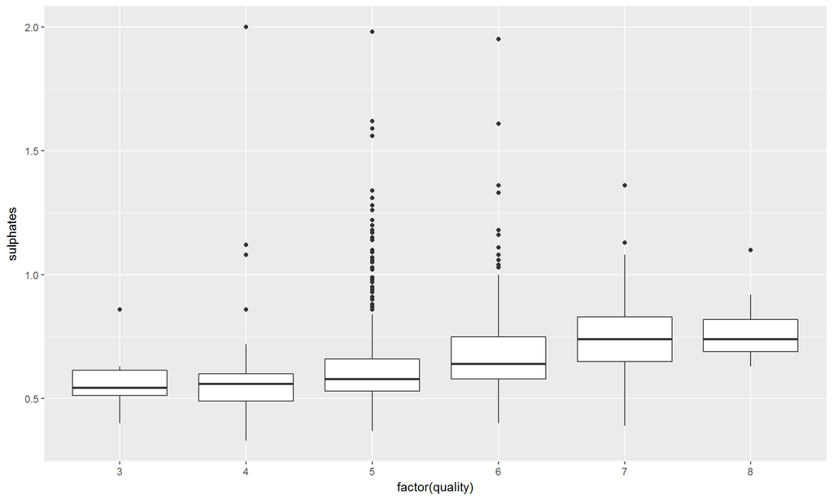

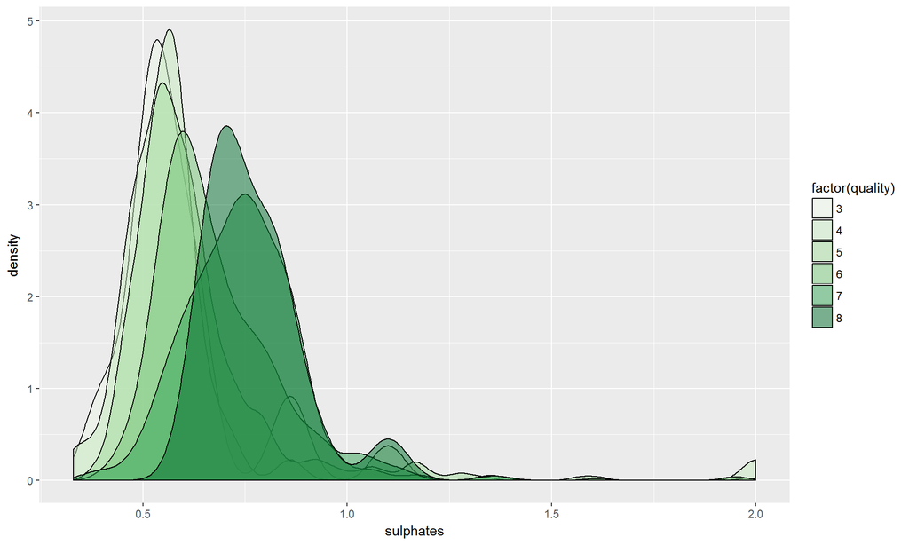

## 4.3 各种酸性物质之间的关系

### fixed.acidity与pH

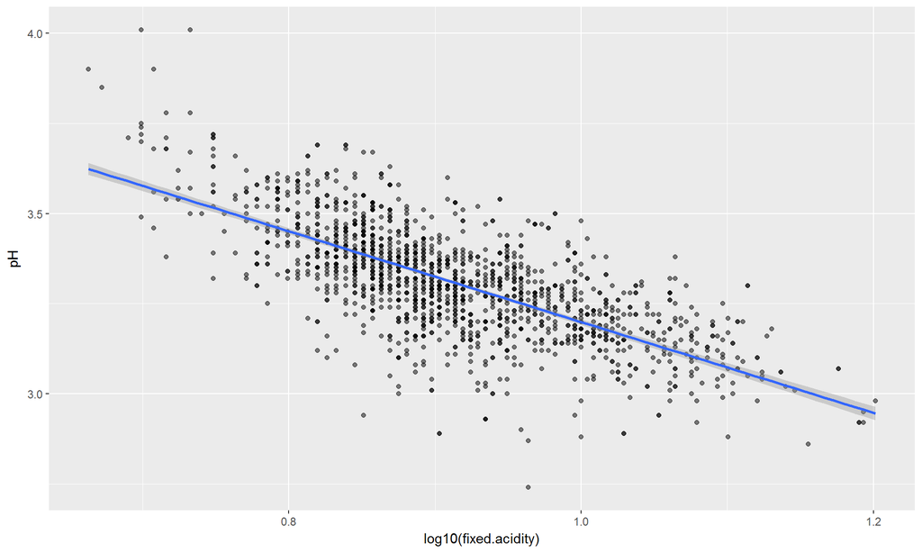

```
## [1] -0.683
```

```
## [1] -0.706
```

```
##    Min. 1st Qu.  Median    Mean 3rd Qu.    Max.
##    4.60    7.10    7.90    8.32    9.20   15.90
```

fixed.acidity与pH的相关系数是-0.68，因为pH值是根据溶液中氢离子含量的对数计算出来的，因此将fixed.acidity取对数，转化坐标后的相关系数是-0.71。

### fixed.acidity与citric.acid

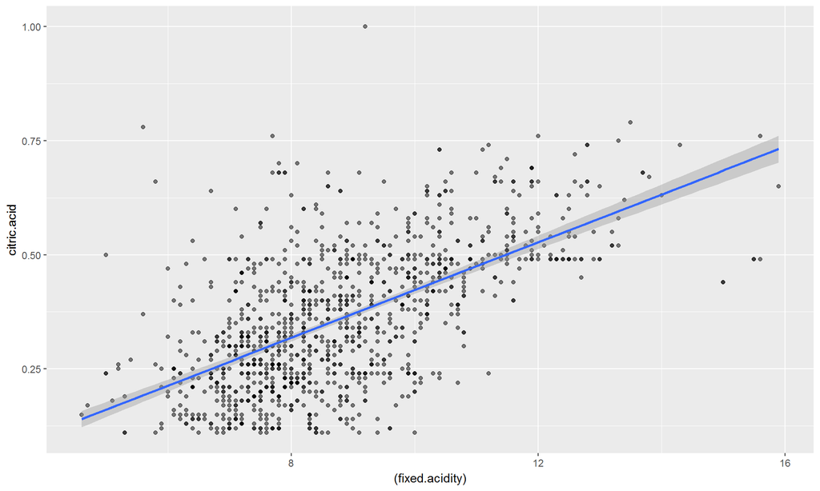

在citric.acid含量较高（大于0.6）时，fixed.acidity和citric.acid相关性并不强，但是当 含量较低时，呈现出正相关性。

### citric.acid与pH

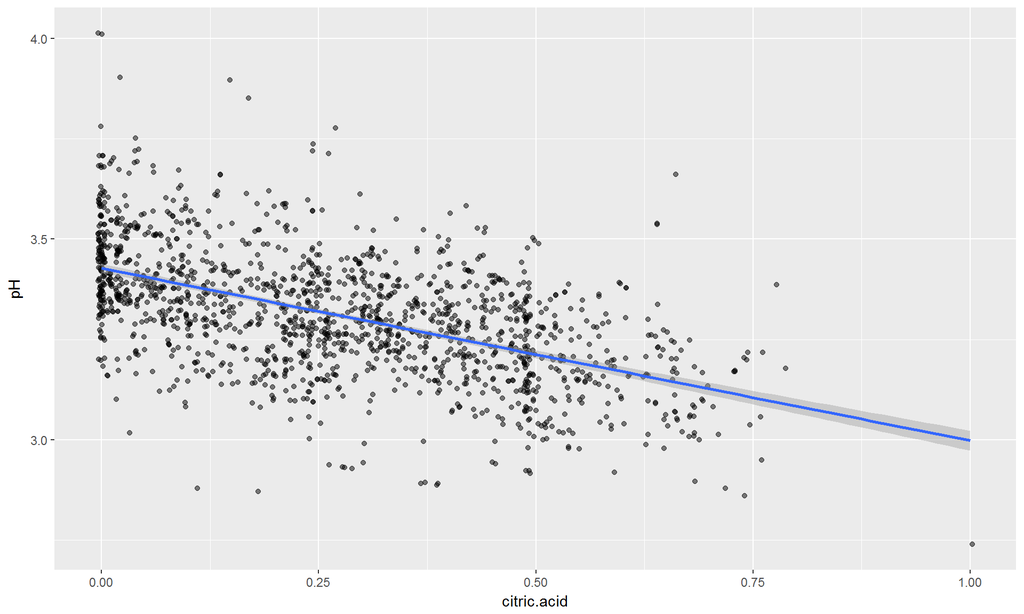

```
## [1] -0.542
```

```
##    Min. 1st Qu.  Median    Mean 3rd Qu.    Max.
##   0.000   0.090   0.260   0.271   0.420   1.000
```

citric.acid与pH相关系数是-0.54，由于citric.acid含量大约是fixed.acidity的3%，因此对pH的影响要小一些。

### citric.acid与density

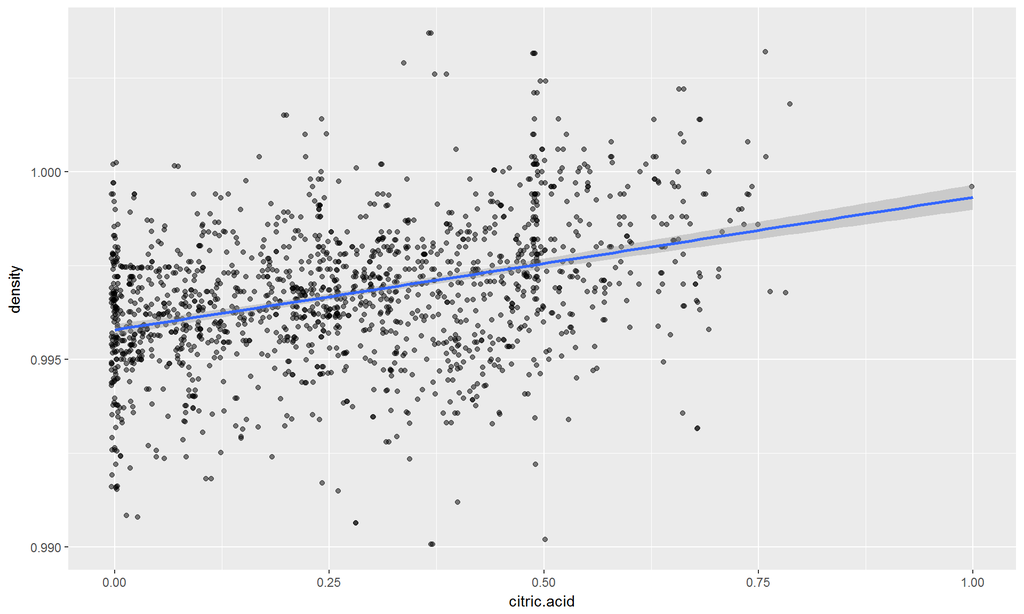

### residual.sugar和density

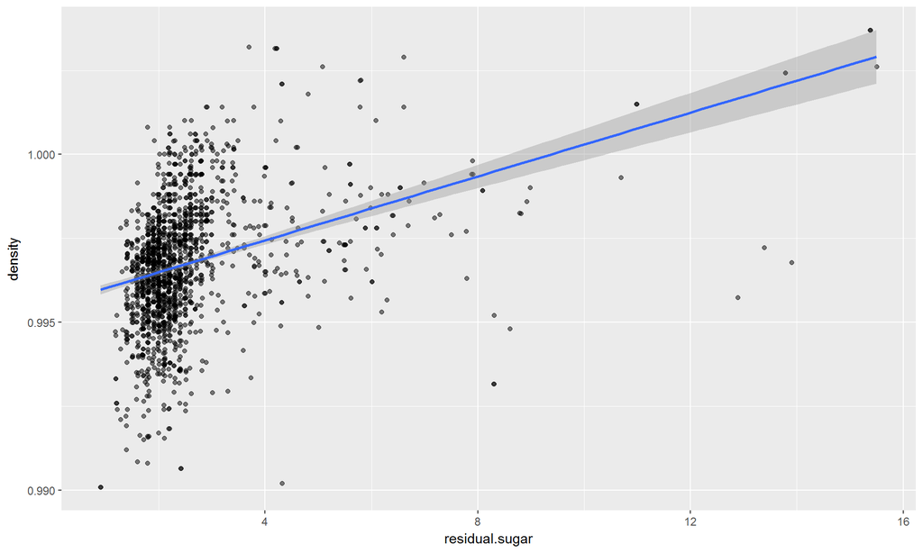

```
##    Min. 1st Qu.  Median    Mean 3rd Qu.    Max.
##    0.90    1.90    2.20    2.54    2.60   15.50
```

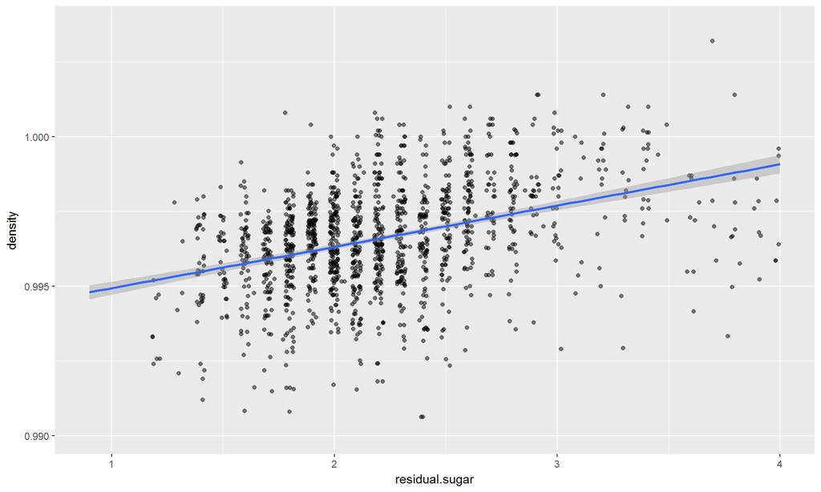

```
##    Min. 1st Qu.  Median    Mean 3rd Qu.    Max.
##    0.90    1.90    2.20    2.54    2.60   15.50
```

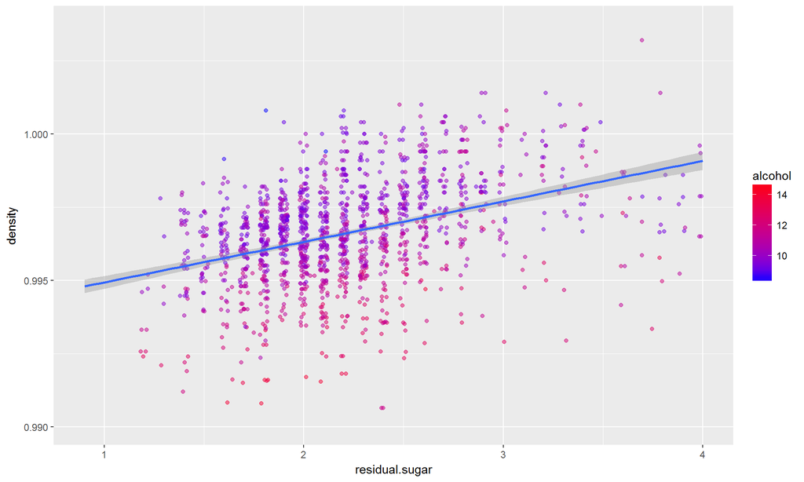

### free.sulfur.dioxide和total.sulfur.dioxide

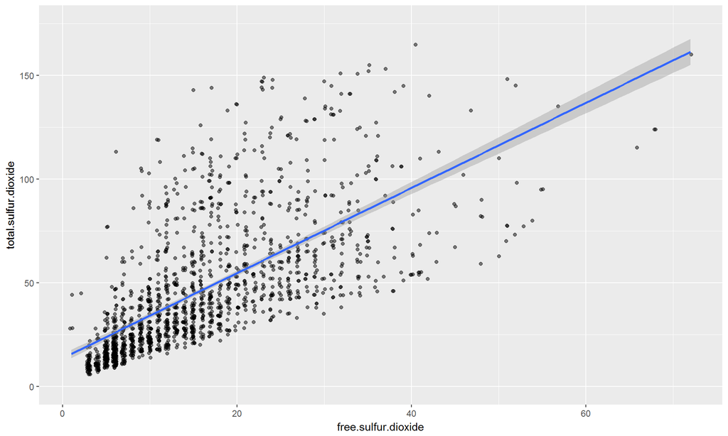

```
## [1] 0.668
```

free.sulfur.dioxide和total.sulfur.dioxide有较强的正相关性，而且随着free.sulfur.dioxide的增大，方差也在变大。

### chlorides和sulphates

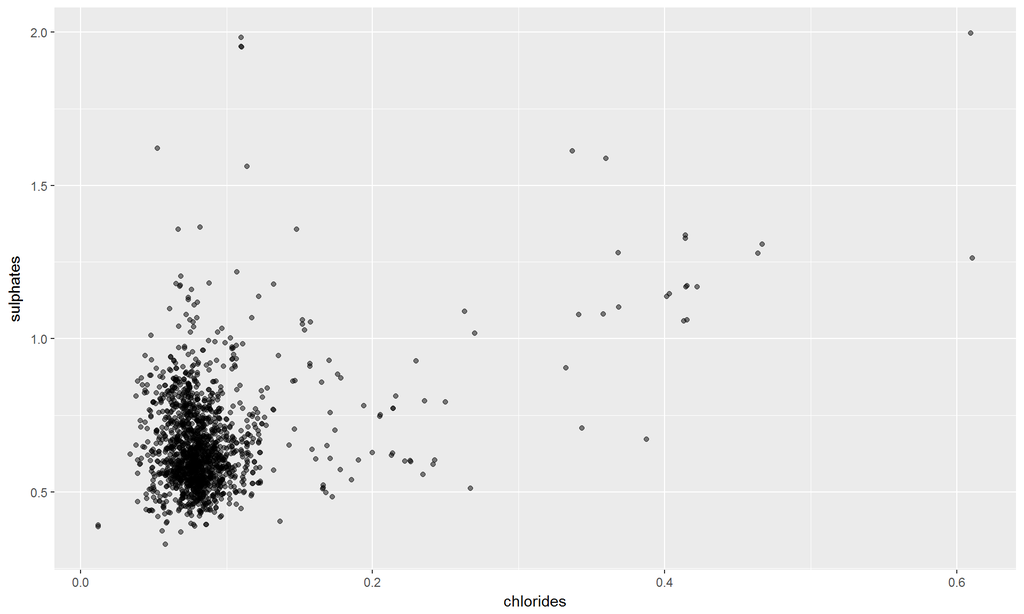

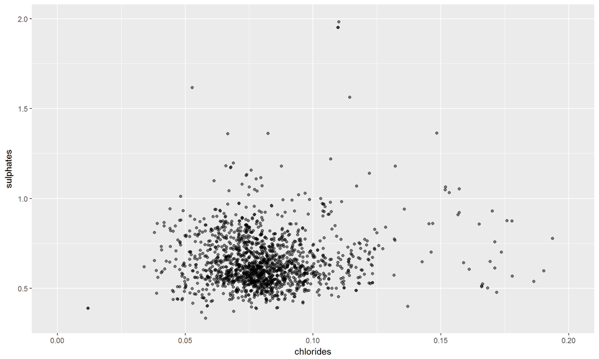

由于chlorides存在异常值，使得相关系数算出来较大（0.37），但是分析散点图可以看出，两者并没有什么直接的关系。

### density和alcohol

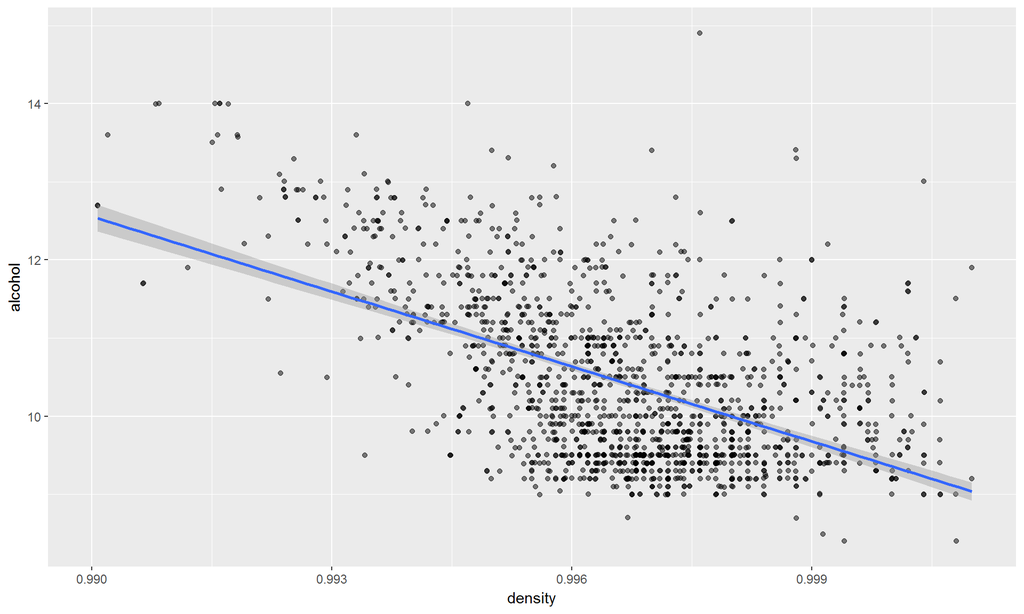

density与alcohol呈现明显负相关关系。

### acid_by_alcohol与density

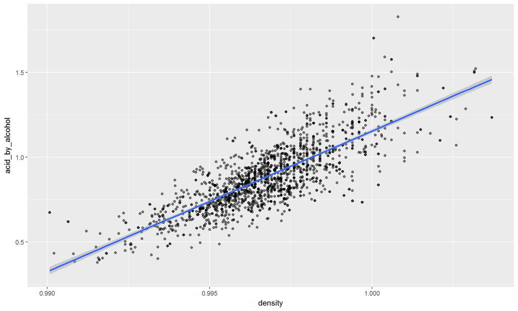

从相关系数可以看出，acid_by_alcohol与fixed.acidity、alcohol、pH值之间有较强相关性，这些都容易理解，因为构造该特征就是利用了这些变量。但是一个例外的发现是，acid_by_alcohol与density也有很强的关系。

## 两变量分析

### **谈一谈在这部分你观察到的一些关系。这些你感兴趣的特征之间是如何变化的？**

红酒的品质主要和酒精含量和挥发性酸含量有关。

alcohol和quality呈正相关，当quality增大时，alcohol分布变宽。

### **除了你感兴趣的特征，你还观察到了其他有意思的关系吗？**

pH主要和fixed.acidity的含量有关，并且将fixed.acidity坐标取对数后，相关系数由原来的-0.68提升至-0.71。这与pH的定义是吻合的。

去除糖分中的异常值，发现糖分和密度存在较强的相关性。

free.sulfur.dioxide和total.sulfur.dioxide有较强的正相关性，而且随着free.sulfur.dioxide的增大，方差也在变大。

acid_by_alcohol与density有很强的线性关系。

### **哪种关系之间相关性最强？**

红酒质量和酒精含量之间相关性最大，在其他特征中，pH值和fixed.acidity含量之间相关性最大。

# 5.多变量画图

## 5.1 quality、volatile.acidity、citric.acidity的关系

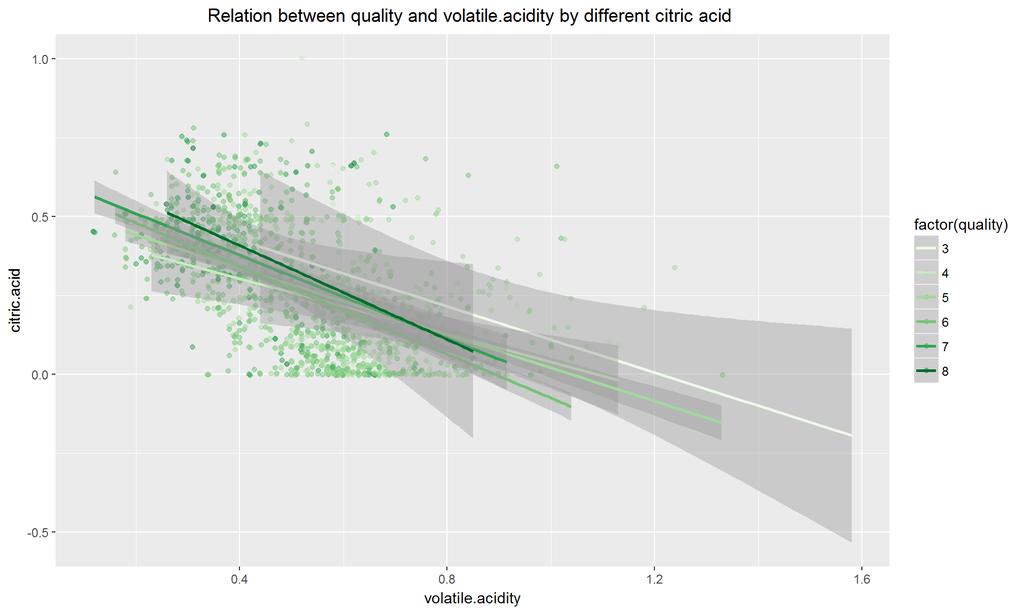

柠檬酸与挥发性酸之间存在负相关关系，但是在不同的quality下，斜率基本信息相同，这说明柠檬酸含量对质量影响不大。

## 5.2 quality, alcohol, density

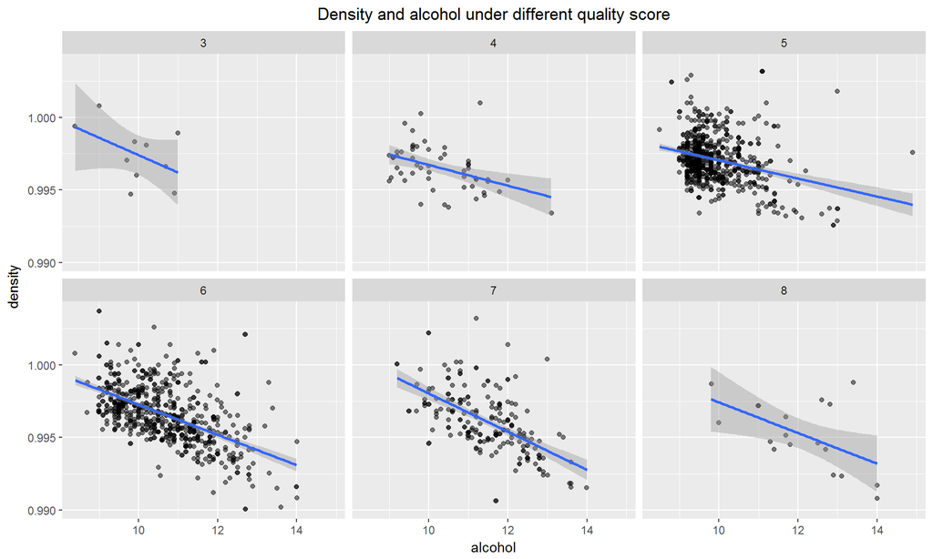

对于不同品质的红酒，密度和酒精含量均呈现负相关,拟合的斜率差别并不大。但是在quality=3、4、8的数据点比较稀疏，所以需要更多的数据点，才能给出更有说服力的结论。

## 5.3 density、alcohol、residual.sugar

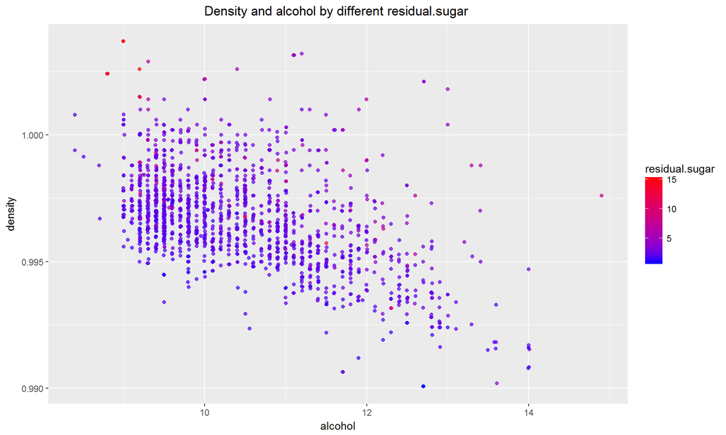

密度和酒精含量成负相关，和糖分含量成正相关。

## 5.4 quality、alcohol、acid_by_alcohol

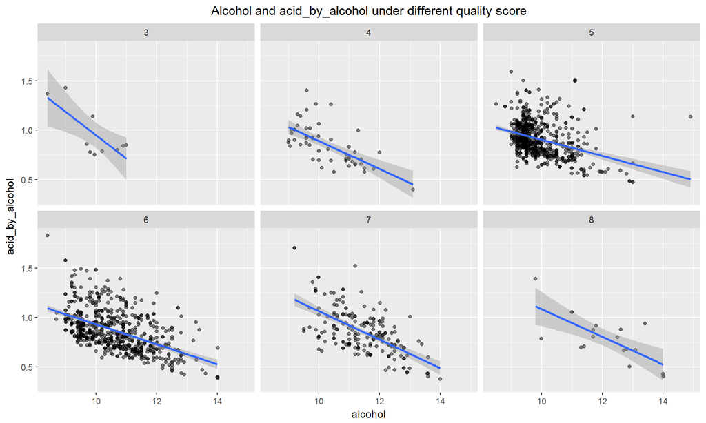

[figure not shown]

quality的分布方差很大，不同的quality下，acid_by_alcohol与alcohol线性关系并没有什么不同。

## 5.5 建立模型

```
##
## Calls:
## m1: lm(formula = I(quality) ~ I(alcohol), data = Redwine)
## m2: lm(formula = I(quality) ~ I(alcohol) + volatile.acidity, data = Redwine)
## m3: lm(formula = I(quality) ~ I(alcohol) + volatile.acidity + citric.acid,
##     data = Redwine)
## m4: lm(formula = I(quality) ~ I(alcohol) + volatile.acidity + citric.acid +
##     density, data = Redwine)
##
## ============================================================================
##                          m1            m2            m3            m4
## ----------------------------------------------------------------------------
##   (Intercept)           1.875***      3.095***      3.055***    -21.552
##                        (0.175)       (0.184)       (0.194)      (12.039)
##   I(alcohol)            0.361***      0.314***      0.314***      0.336***
##                        (0.017)       (0.016)       (0.016)       (0.019)
##   volatile.acidity                   -1.384***     -1.343***     -1.399***
##                                      (0.095)       (0.114)       (0.117)
##   citric.acid                                       0.068        -0.061
##                                                    (0.103)       (0.121)
##   density                                                        24.520*
##                                                                 (11.994)
## ----------------------------------------------------------------------------
##   R-squared             0.227         0.317         0.317         0.319
##   adj. R-squared        0.226         0.316         0.316         0.317
##   sigma                 0.710         0.668         0.668         0.667
##   F                   468.267       370.379       246.976       186.646
##   p                     0.000         0.000         0.000         0.000
##   Log-likelihood    -1721.057     -1621.814     -1621.596     -1619.503
##   Deviance            805.870       711.796       711.603       709.742
##   AIC                3448.114      3251.628      3253.192      3251.006
##   BIC                3464.245      3273.136      3280.078      3283.269
##   N                  1599          1599          1599          1599
## ============================================================================
```

虽然建立了模型，但是预测能力并不好，$R^2\approx 0.319$，从分析过程来看，确实发现quality和目前变量之间相关性较弱，可能需要更有效的特征。

## 多变量分析

### **关于感兴趣的特征，是否存在其他特征之间互相增强的现象？**

在多变量分析过程中，并没有发现其他特征之间的增强现象。这可能是因为选取的特征效果不好，也有可能是数据集不够大。

### **特征之间是否存在有趣的相互作用关系？**

密度和酒精含量成负相关，和糖分含量成正相关。

### **你是否创建了一个模型，讨论一下模型的优势和劣势。**

是，这个模型选取了酒精含量、挥发性酸含量、柠檬酸含量、密度作为特征，采用多元线性回归模型。优势是计算简单，劣势是预测能力比较差。

# 6. 最终图形和总结

## 图1

```
##    Min. 1st Qu.  Median    Mean 3rd Qu.    Max.
##   0.120   0.390   0.520   0.528   0.640   1.580
```

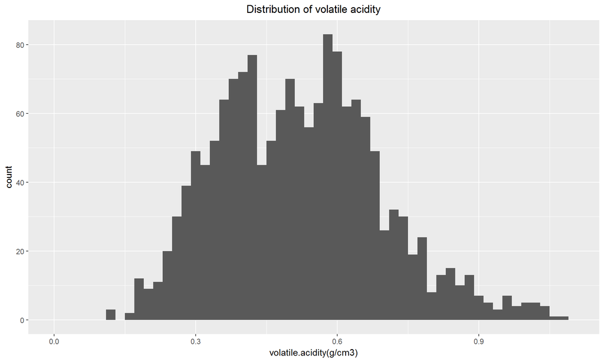

描述1：挥发性酸(volatile.acidity)的分布有两个峰，可能是因为存在两种不同风格的葡萄酒。

## 图2

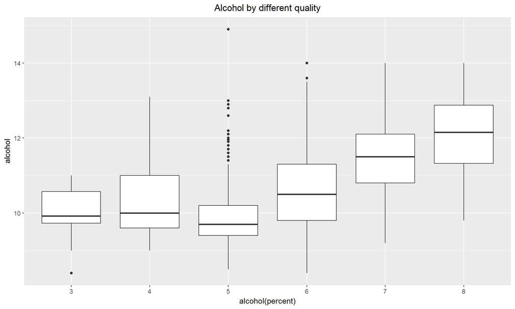

描述2：alcohol和quality呈正相关，当quality增大时，alcohol分布变宽。

## 图3

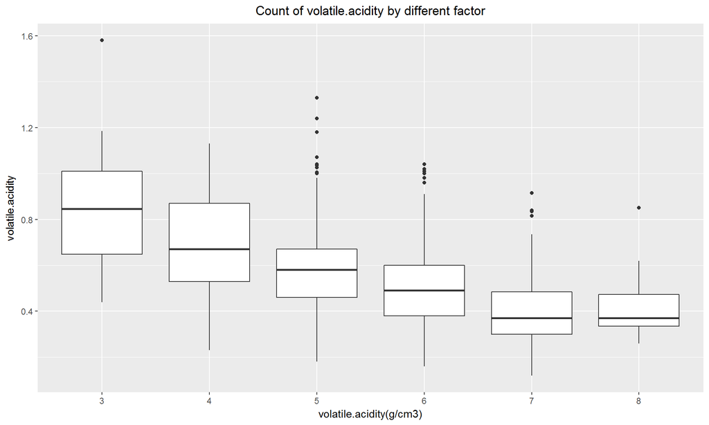

描述3： quality和volatile.acidity呈负相关关系。当volatile.acidity低至0.4时，不再是影响 quality的主要因素。

## 反思

我首先通过单变量分析了每种变量的分布情况，检查是否存在异常值，了解平均数等信息，对数据有一个宏观的把握。然后再分析变量两两之间的关系，特别是红酒的质量与哪些因素关联比较大，发现红酒与酒精度和挥发性酸含量密切相关。除此之外，还发现了其他变量之间的相关性，比如密度和酒精、溶解性硫化物和亚硫酸根含量。最后进行多元分析，看看三个相关系数较高的变量之间是否存在规律。

分析过程中发现有几个问题。第一，红酒质量确实和很多因素关系不大，这意味着数据中有效的特征并不多，但也有可能是我没有构造出好的特征。第二，数据量并不大。例如在分析密度、酒精含量、红酒质量之间的关系时，由于3分的红酒数据量较少，导致某些图数据点稀薄，不能给出有说服力的变量之间的关系。第三，某些特征之间存在很强的相关性，比如溶解性硫化物和亚硫酸根含量，实际建立模型时可以考虑针对这些特征降维。

下一步的建议：首先再收集更多的数据，尤其是quality分布两边的数据，这对于评估不同quality，某些变量之间的线性关系很有用。另外，查阅文献了解到，糖酸比可能对红酒的质量有影响，可以具体分析一下糖酸比这个变量和质量之间的关系。

# 7. 参考资料

- [RColorBrewer包](http://www.cnblogs.com/homewch/p/5704153.html#autoid-0-0-0)
- [Quick correlation matrix heatmap](http://www.sthda.com/english/wiki/ggplot2-quick-correlation-matrix-heatmap-r-software-and-data-visualization)
- [怎样读酒标辨识美酒](http://wine.baike.com/article-1307115.html)